# p8105_hw1_yy3564

Yonghao YU

2024-09-20

## Question 1

First, I load the dataset

```r
data("penguins", package = "palmerpenguins")
```

Then I use inline R code to write a short description:

The name of the dataset is called penguins, the name of each column is species, island, bill_length_mm, bill_depth_mm, flipper_length_mm, body_mass_g, sex, year.  
The size of the dataset is 344 rows and 8 columns.  
The mean fipper length is 200.9152047.

After that I import the library and draw the scatterplot required!

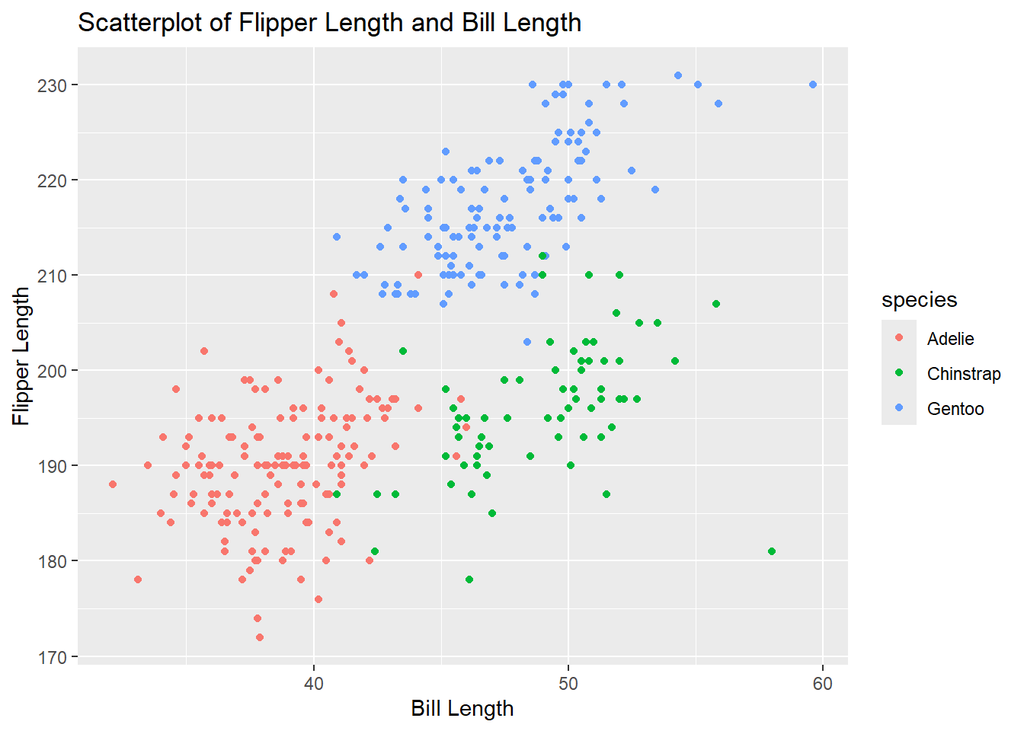

```r
library(tidyverse)
plotrequired = ggplot(penguins, aes(x = bill_length_mm, y = flipper_length_mm, color = species)) +
  geom_point() +
  labs(
    x = "Bill Length",
    y = "Flipper Length",
    title = "Scatterplot of Flipper Length and Bill Length"
  )
plotrequired
```

Then I save the plot I have produced!

```r
ggsave(filename = "scatterplot_penguins.png", plot = plotrequired)
```

## Question 2

Set the random seed and load the tidyverse package as required

```r
set.seed(200)
library(tidyverse)
```

```r
# First, create a random sample of size 10
sample = rnorm(10)

# Second, create a logical vector
logical = sample > 0

# Third, create a character vector
character = paste("Value", 1:10)

# Last, create a factor vector
factor = factor(sample(c("Level 1", "Level 2", "Level 3"), 10, replace = TRUE))
```

Conbine them into one dataframe and display it!

```r
data_frame = data.frame(
  Sample = sample,
  Logical = logical,
  Character = character,
  Factor = factor
)
print(data_frame)
```

```
##         Sample Logical Character  Factor
## 1   0.08475635    TRUE   Value 1 Level 3
## 2   0.22646034    TRUE   Value 2 Level 3
## 3   0.43255650    TRUE   Value 3 Level 2
## 4   0.55806524    TRUE   Value 4 Level 1
## 5   0.05975527    TRUE   Value 5 Level 2
## 6  -0.11464087   FALSE   Value 6 Level 2
## 7  -1.02057835   FALSE   Value 7 Level 3
## 8  -0.29705130   FALSE   Value 8 Level 2
## 9   0.16815003    TRUE   Value 9 Level 3
## 10  1.41987233    TRUE  Value 10 Level 3
```

Then calculate the mean for each columns one by one to check whether there are any problems during the calculations!

```r
Sample_mean = mean(data_frame %>% pull(Sample))
Sample_mean
```

```
## [1] 0.1517346
```

```r
Logical_mean = mean(data_frame %>% pull(Logical))
Logical_mean
```

```
## [1] 0.7
```

```r
Character_mean = mean(data_frame %>% pull(Character))
Character_mean
```

```
## [1] NA
```

```r
Factor_mean = mean(data_frame %>% pull(Factor))
Factor_mean
```

```
## [1] NA
```

When I print out these values, it shows obviously that the random sample and logical vector work and the charactor vector and the factor vector do not work!!!

Then converting variables to numeric using pull function

```r
numeric_logical_vector = as.numeric(data_frame %>% pull(Logical))
```

```r
numeric_character_vector = as.numeric(data_frame %>% pull(Character))
numeric_factor_vector = as.numeric(data_frame %>% pull(Factor))
```

showing the code chunk but not checking the outputs

```r
numeric_logical_vector
numeric_character_vector
numeric_factor_vector
```

Convert Logical vector to Numeric: Converting TRUE to 1 and FALSE to 0, then take the mean of numerous 0 and 1!!!!!

Convert Character vector to Numeric: Converting makes all entries NA because the strings can’t be converted to numbers!!!!!

Convert Factor vector to Numeric: Converting the factor levels to underlying integer, which allows for mean calculations but it is meaningless because it is just some meaningless numbers and it does not have the original categorical interpretation anymore!!!!!